# Cyclistic Bike Sharing

A. Ujjwal

2022-07-26

## Scenario

You are a junior data analyst working in the marketing analyst team at Cyclistic, a bike-share company in Chicago. The director of marketing believes the company’s future success depends on maximizing the number of annual memberships. Therefore, your team wants to understand how casual riders and annual members use Cyclistic bikes differently. From these insights, your team will design a new marketing strategy to convert casual riders into annual members. But first, Cyclistic executives must approve your recommendations, so they must be backed up with compelling data insights and professional data visualizations.

With a growing fleet of 5824 bicycles along with 692 docking stations, the fictional bike-share company was founded in 2016, and has a wide user base, grouped as:

- Casual : customers who purchase single-ride or full-day passes
- Members : customers who purchase annual memberships

## Objectives

As per Cyclistic’s finance analysts, three questions will guide the future marketing programs:

1. How do annual members and casual riders use Cyclistic bikes differently?
2. Why would casual riders buy Cyclistic annual memberships?
3. How can Cyclistic use digital media to influence casual riders to become members?

## Preparing Data

The data is stored on AWS cloud and is named correctly and easily downloadable. For this project, I have used data from the year 2021.

Once downloaded, the data is extracted from the ZIP files and stored locally for further analysis on RStudio Desktop. As the data is large, neither spreadsheets nor RStudio Cloud were operable.

Furthermore, the downloaded data is reliable, original, comprehensive, current and is cited by the company.

### Processing Data

Before starting with the analysis, the data needs to be in an orderly manner. In this step, the monthly data is integrated, followed by deleting the NA values, and then inserting a few calculated fields in the original, integrated data frame.

### Loading the Required libraries

The ‘tidyverse’ package comprises of 8 smaller packages like dplyr, readr, ggplot2, purrr, tibble, tidyr, stringr and forcats. The ‘tidyverse’ package is a one stop solution for all analytics operations in R.

The lubridate library is used to work with dates in R, whereas the janitor library has functions that help in cleaning the data.

```r
library(tidyverse)
library(lubridate)
library(janitor)
```

### Loading the monthly datasets

The monthly datasets are loaded/accessesed and renamed for better usability during analysis.

```r
jan_2021<-read_csv( "data-csv/202101-divvy-tripdata.csv" )
feb_2021<-read_csv( "data-csv/202102-divvy-tripdata.csv" )
mar_2021<-read_csv( "data-csv/202103-divvy-tripdata.csv" )
apr_2021<-read_csv( "data-csv/202104-divvy-tripdata.csv" )
may_2021<-read_csv( "data-csv/202105-divvy-tripdata.csv" )
jun_2021<-read_csv( "data-csv/202106-divvy-tripdata.csv" )
jul_2021<-read_csv( "data-csv/202107-divvy-tripdata.csv" )
aug_2021<-read_csv( "data-csv/202108-divvy-tripdata.csv" )
sep_2021<-read_csv( "data-csv/202109-divvy-tripdata.csv" )
oct_2021<-read_csv( "data-csv/202110-divvy-tripdata.csv" )
nov_2021<-read_csv( "data-csv/202111-divvy-tripdata.csv" )
dec_2021<-read_csv( "data-csv/202112-divvy-tripdata.csv" )
```

### Compare the monthly dataframes for congruency

Since the data frames have been segregated by month, it would be a good practice to check and compare all the data frames for congruency before proceeding further to merge the data.

```r
compare_df_cols (jan_2021, feb_2021, mar_2021, apr_2021, may_2021, jun_2021, jul_2021, aug_2021, sep_2021, oct_2021, nov_2021, dec_2021)
```

```
##           column_name        jan_2021        feb_2021        mar_2021
## 1             end_lat         numeric         numeric         numeric
## 2             end_lng         numeric         numeric         numeric
## 3      end_station_id       character       character       character
## 4    end_station_name       character       character       character
## 5            ended_at POSIXct, POSIXt POSIXct, POSIXt POSIXct, POSIXt
## 6       member_casual       character       character       character
## 7             ride_id       character       character       character
## 8       rideable_type       character       character       character
## 9           start_lat         numeric         numeric         numeric
## 10          start_lng         numeric         numeric         numeric
## 11   start_station_id       character       character       character
## 12 start_station_name       character       character       character
## 13         started_at POSIXct, POSIXt POSIXct, POSIXt POSIXct, POSIXt
##           apr_2021        may_2021        jun_2021        jul_2021
```

[output cut: 41 more lines]

From this step, it’s clear that all the corresponding columns from the monthly data frames have the same name and data types. We’re good to go!

### Merging the data frames

Let’s merge the data frames to proceed further with the analysis.

```r
all_trips<- rbind(jan_2021, feb_2021, mar_2021, apr_2021, may_2021, jun_2021, jul_2021, aug_2021, sep_2021, oct_2021, nov_2021, dec_2021)
```

When we check the structure of the new, integrated data frame, we observe that the monthly data frames have been successfully bound. We can also see that some columns have NA values.

```r
str(all_trips)
```

```
## spec_tbl_df [5,595,063 × 13] (S3: spec_tbl_df/tbl_df/tbl/data.frame)
##  $ ride_id           : chr [1:5595063] "E19E6F1B8D4C42ED" "DC88F20C2C55F27F" "EC45C94683FE3F27" "4FA453A75AE377DB" ...
##  $ rideable_type     : chr [1:5595063] "electric_bike" "electric_bike" "electric_bike" "electric_bike" ...
##  $ started_at        : POSIXct[1:5595063], format: "2021-01-23 16:14:19" "2021-01-27 18:43:08" ...
##  $ ended_at          : POSIXct[1:5595063], format: "2021-01-23 16:24:44" "2021-01-27 18:47:12" ...
##  $ start_station_name: chr [1:5595063] "California Ave & Cortez St" "California Ave & Cortez St" "California Ave & Cortez St" "California Ave & Cortez St" ...
##  $ start_station_id  : chr [1:5595063] "17660" "17660" "17660" "17660" ...
##  $ end_station_name  : chr [1:5595063] NA NA NA NA ...
##  $ end_station_id    : chr [1:5595063] NA NA NA NA ...
##  $ start_lat         : num [1:5595063] 41.9 41.9 41.9 41.9 41.9 ...
##  $ start_lng         : num [1:5595063] -87.7 -87.7 -87.7 -87.7 -87.7 ...
##  $ end_lat           : num [1:5595063] 41.9 41.9 41.9 41.9 41.9 ...
##  $ end_lng           : num [1:5595063] -87.7 -87.7 -87.7 -87.7 -87.7 ...
##  $ member_casual     : chr [1:5595063] "member" "member" "member" "member" ...
##  - attr(*, "spec")=
##   .. cols(
##   ..   ride_id = col_character(),
##   ..   rideable_type = col_character(),
##   ..   started_at = col_datetime(format = ""),
##   ..   ended_at = col_datetime(format = ""),
##   ..   start_station_name = col_character(),
##   ..   start_station_id = col_character(),
##   ..   end_station_name = col_character(),
##   ..   end_station_id = col_character(),
##   ..   start_lat = col_double(),
##   ..   start_lng = col_double(),
##   ..   end_lat = col_double(),
##   ..   end_lng = col_double(),
##   ..   member_casual = col_character()
##   .. )
##  - attr(*, "problems")=<externalptr>
```

Before proceeding further, we will delete the NA values. While we are at it, we should also delete the month-wise data frames to clear system memory.

```r
all_trips<- drop_na(all_trips) # Removes all NA values from the data frame "all_trips"

rm(jan_2021, feb_2021, mar_2021, apr_2021, may_2021, jun_2021, jul_2021, aug_2021, sep_2021, oct_2021, nov_2021, dec_2021) # Removes all surplus data frames
```

### Inserting the Calculated Fields in the data frame

Before we start analyzing, we have to calculate the duration of each ride. TO do so, we need to calculate the difference between the end and start time of each ride. We also need to find out which day of the week a particular ride took place on. While we are at it, let’s add a new field Month. This field will be useful in our analysis.

```r
all_trips<- mutate( all_trips, trip_duration= round(difftime( all_trips$ended_at, all_trips$started_at, units = 'mins' ), 3)) %>%
  mutate( Weekday= weekdays(all_trips$started_at), Month=month.abb[month(all_trips$started_at)])
```

We will now check the range of the newly calculated field ‘trip_duration’. By doing this, we can find out if there is any bad data.

```r
range(all_trips$trip_duration)
```

```
## Time differences in mins
## [1]   -55.90 55944.15
```

As we see, the minimum time is -3354 seconds. To remove this bad data, we use the following code:

```r
all_trips<- all_trips[all_trips$trip_duration>0, ]
```

Before moving on to the next step, we should arrange the data in ascending order as per the starting date.

```r
all_trips<- arrange(all_trips, all_trips$started_at)
```

### Descriptive Analysis

In this step, we conduct a descriptive analysis on the cleaned data. We will now dive deep into what story the data is telling us.

- Average trip duration

```r
mean(all_trips$trip_duration)
```

```
## Time difference of 21.81192 mins
```

- Median of trip duration

```r
median(all_trips$trip_duration)
```

```
## Time difference of 12.2 mins
```

- Maximum trip duration

```r
max(all_trips$trip_duration)
```

```
## Time difference of 55944.15 mins
```

- Minimum trip duration

```r
min(all_trips$trip_duration)
```

```
## Time difference of 0.017 mins
```

Now, let’s find out how the rides of casual riders differ from the members. We will again find the mean, median, maximum and minimum trip duration, but this time, we will group them by the riders’ membership types, namely casual and member.

- Average of trip duration

```r
mean_by_membership<- aggregate(all_trips$trip_duration~all_trips$member_casual, FUN=mean)
colnames(mean_by_membership)<- c("Membership Type", "Average Trip Duration")
mean_by_membership
```

```
##   Membership Type Average Trip Duration
## 1          casual         32.51015 mins
## 2          member         13.18401 mins
```

- Median of trip duration

```r
median_by_membership<-aggregate(all_trips$trip_duration~all_trips$member_casual, FUN=median)
colnames(median_by_membership)<- c("Membership Type", "Median of Trip Duration")
median_by_membership
```

```
##   Membership Type Median of Trip Duration
## 1          casual             16.650 mins
## 2          member              9.717 mins
```

- Maximum trip duration

```r
max_by_membership<-aggregate(all_trips$trip_duration~all_trips$member_casual, FUN=max)
colnames(max_by_membership)<- c("Membership Type", "Maximum Duration")
max_by_membership
```

```
##   Membership Type Maximum Duration
## 1          casual   55944.150 mins
## 2          member    1495.633 mins
```

- Minimum trip duration

```r
min_by_membership<-aggregate(all_trips$trip_duration~all_trips$member_casual, FUN=min)
colnames(min_by_membership)<- c("Mebership Type", "Minimum Trip Duration")
min_by_membership
```

```
##   Mebership Type Minimum Trip Duration
## 1         casual            0.017 mins
## 2         member            0.017 mins
```

## Exporting the cleaned data frame

The data has been cleaned and is ready for further analysis. The cleaned data set is ready to be exported for further analysis.

```r
write.csv( all_trips,"C:/Users/Ayushya Ujjwal/Desktop/all_trips.csv")
## Visualizing the findings
```

## VISUALIZATION

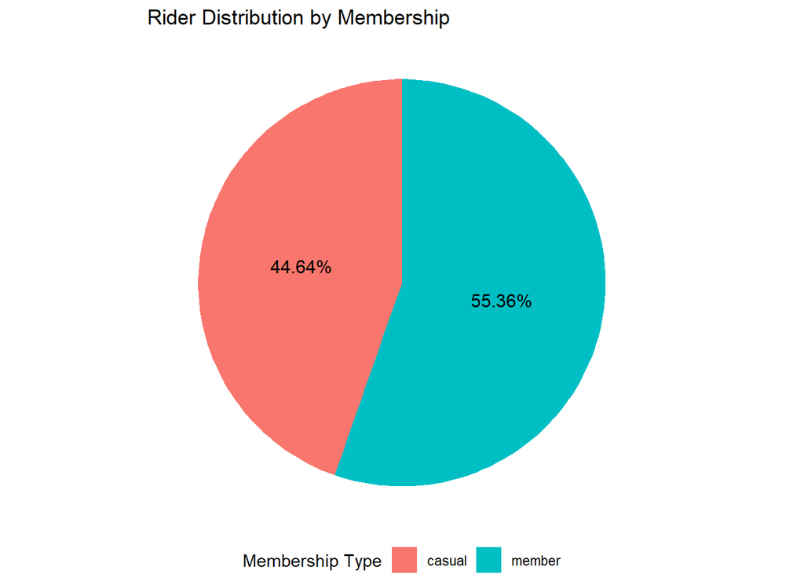

Let’s take a look at the most popular bike type.

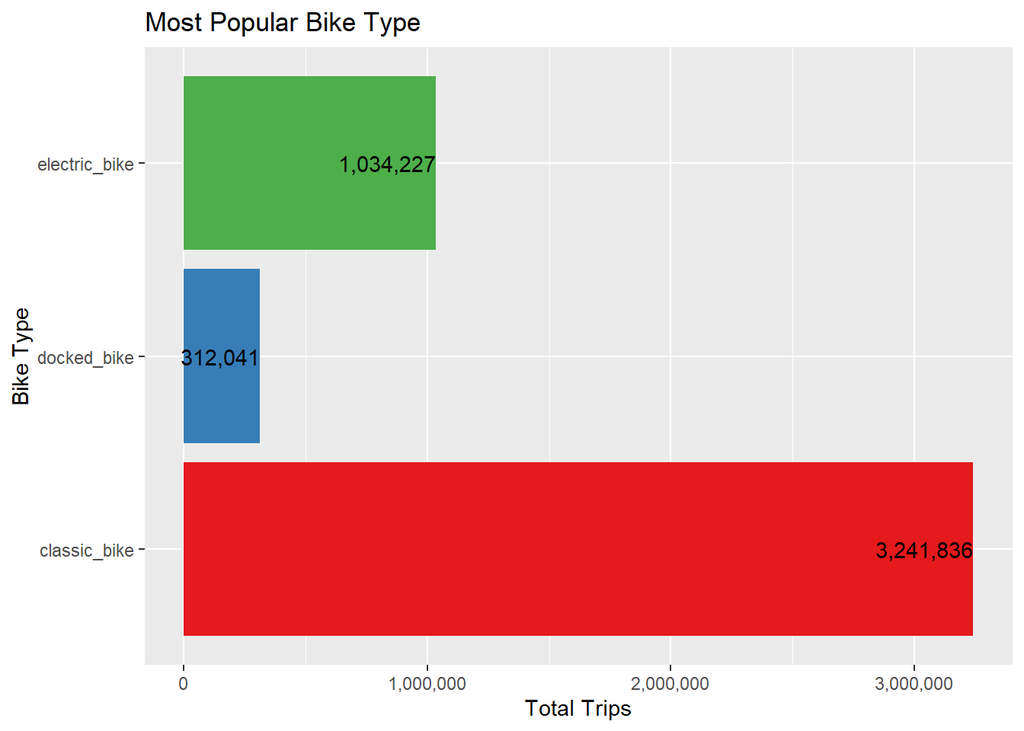

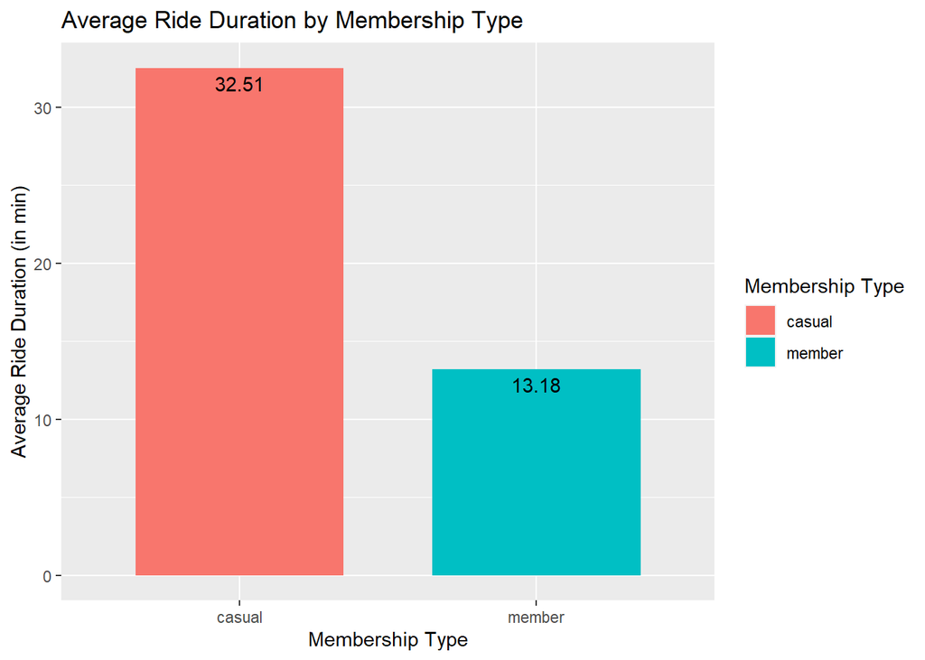

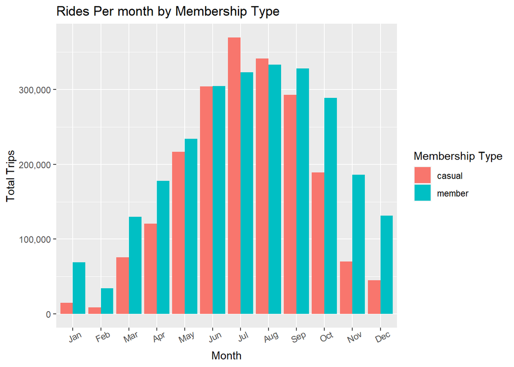

```
## Defaulting to continuous.
## Defaulting to continuous.
```

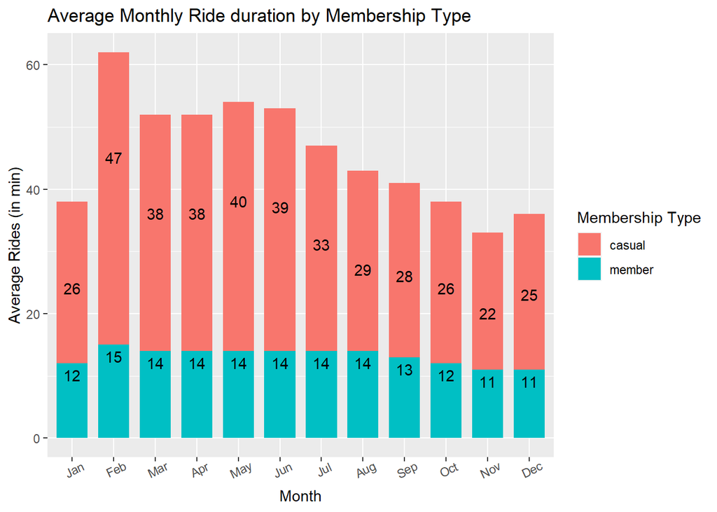

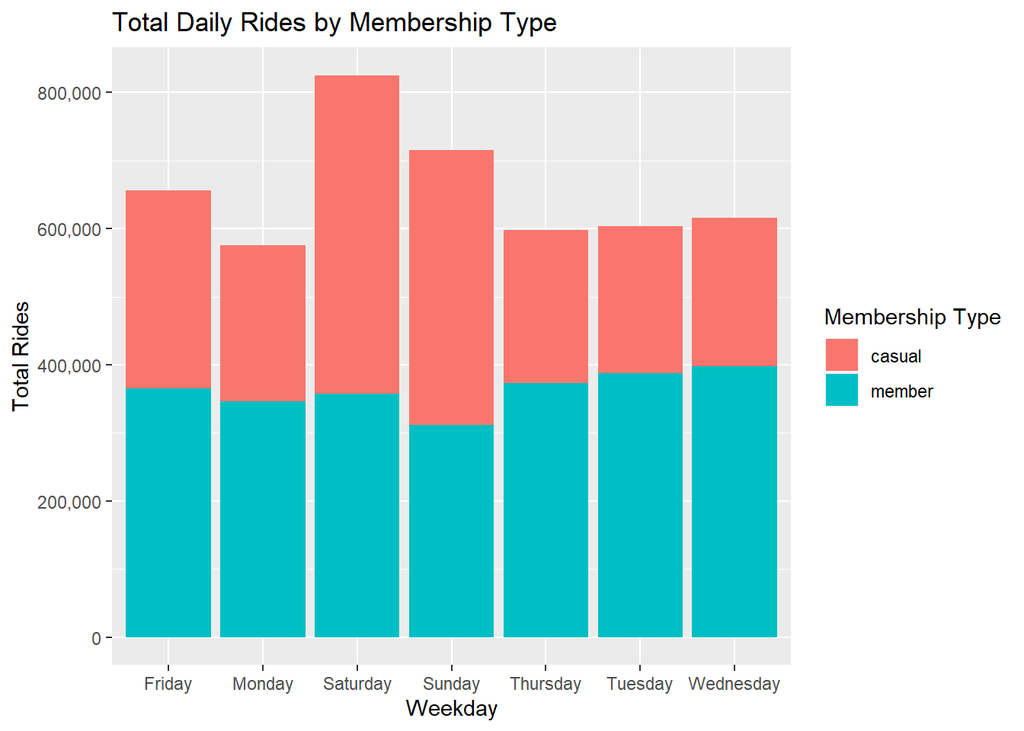

Also, lets look at how the average ride duration fares throughout the week for both the groups.

```
## Defaulting to continuous.
## Defaulting to continuous.
```

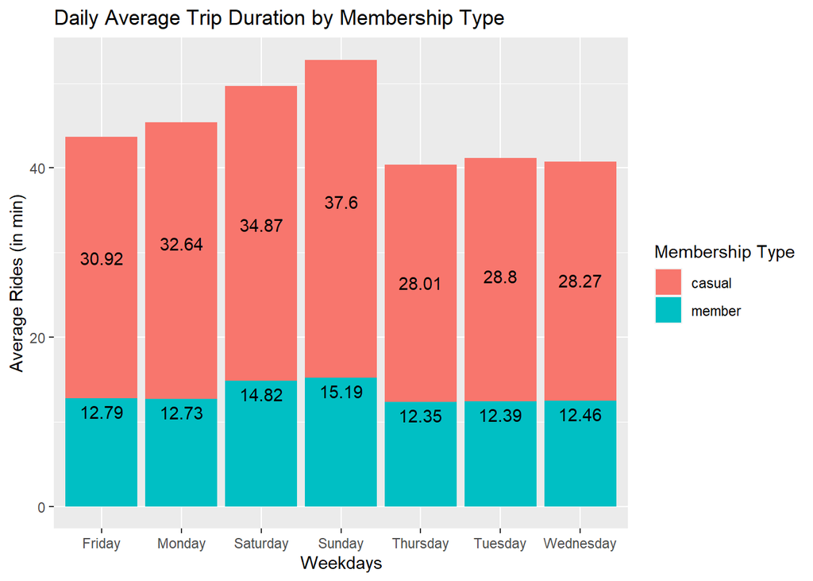

```r
all_trips %>%
  group_by(member_casual, Weekday) %>%
  summarise(avg_ride_duration=round(mean(trip_duration), 2)) %>%
  ggplot(aes(x=Weekday, y=avg_ride_duration, fill=member_casual))+
  geom_col()+
  ggtitle("Daily Average Trip Duration by Membership Type")+
  xlab("Weekdays")+
  ylab("Average Rides (in min)")+
  scale_fill_discrete(name='Membership Type')+
  geom_text(aes(label = avg_ride_duration), vjust = 1.5, colour = "black")
```

Let’s find out which stations are the most and preferred by the users.

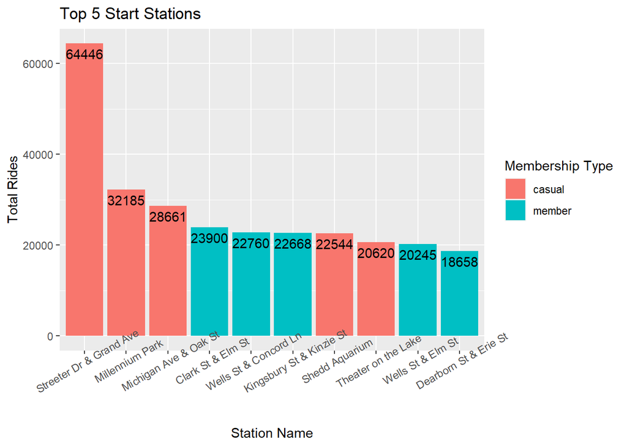

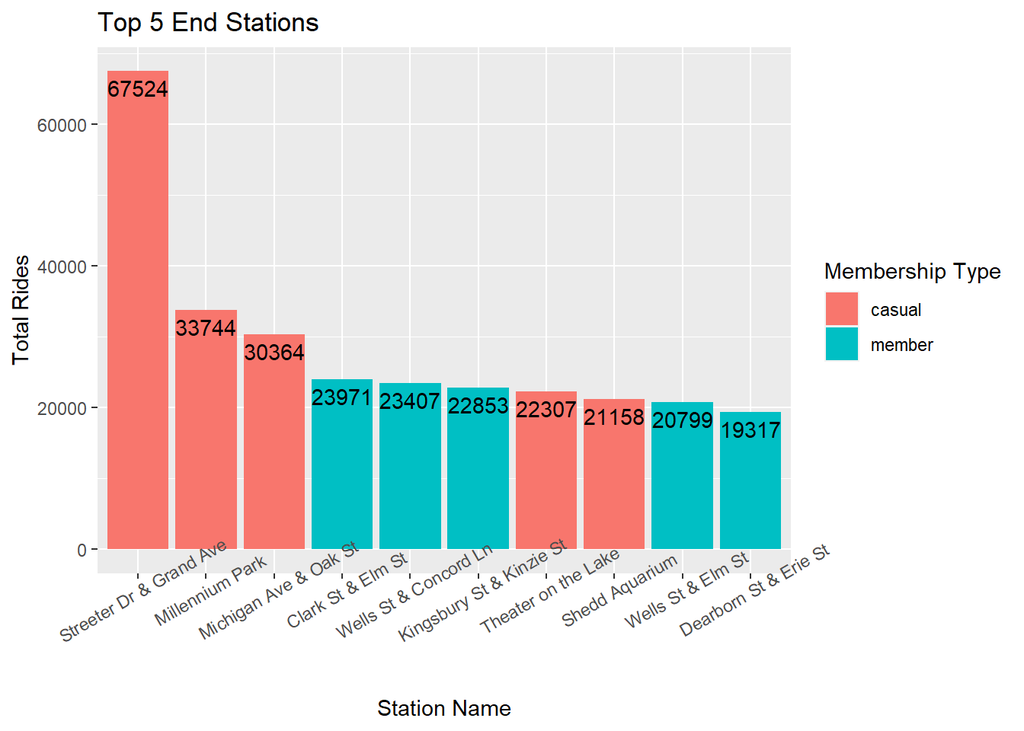

```r
all_trips %>%
  group_by(member_casual, end_station_name) %>%
  summarise(number_of_trips=n()) %>%
  arrange(desc(number_of_trips)) %>%
  slice(1:5) %>%
  ggplot(aes(x=reorder(end_station_name, -number_of_trips), y=number_of_trips, fill= member_casual))+
  geom_col()+
  ggtitle("Top 5 End Stations")+
  xlab("Station Name")+
  ylab("Total Rides")+
  theme(axis.text.x = element_text(angle = 30))+
  scale_fill_discrete(name='Membership Type')+
  geom_text(aes(label = number_of_trips), vjust = 1.5, colour = "black")
```